# Introduction to <code>rmarkdown</code>

## Introduction to `rmarkdown`

*Anna Krystalli & Mike Croucher*

#### **ISBE 2016**

##### *'Challenge for our generation: open, reproducible and reliable science'*

## markdown `.md`

> stripped down **`html`**
- intended to be as **easy-to-read** and **easy-to-write** as possible.
- intended for one purpose: to be used as a **format for writing for the web.**
- syntax is very small, corresponding only to a very small subset of HTML tags.

## focus on communicating & disseminating

- formatting handled automatically
- clean and legible across platforms and outputs

## rmarkdown `.Rmd`

#### enables literate programming

single document to integrate data analysis with textual representations, **linking data, code, and text**

### `rmarkdown` integrates:

– **a documentantion language (`.md`)**

with:

– **a programming language (`R`)**

## outputs

[figure not shown]

## it's already everywhere!

- [github READMEs; eg rOpensci taxise README](https://github.com/ropensci/taxize)
- [stackoverflow: eg plot coordinates on a map](http://stackoverflow.com/questions/23130604/r-plot-coordinates-on-map)
- [github.io websites: eg Andy South's blog](http://andysouth.github.io/blog-setup/)

# `Rmarkdown` & reproducibility

> Computational science has led to exciting new developments:
- **Technology is increasing data collection throughput; data are more complex and highdimensional**
- **Existing databases can be merged to become bigger databases**
- **Computing power allows more sophisticated analyses, even on “small” data**
- **For every field “X” there is a “Computational X”**

**Increasing computational complexity of analyses:**

> has exposed limitations in our ability to evaluate published findings.
- **Even basic analyses difficult to describe**
- **Errors more easily introduced into long analysis pipelines**
- **Knowledge transfer is inhibited**
- **Results are difficult to replicate or reproduce**
- **Complicated analyses cannot be trusted**

## calls for reproducibility

> Reproducibility has the potential to serve as a minimum standard for judging scientific claims when full independent replication of a study is not possible.
- fully scripted analyses
- make code and data available

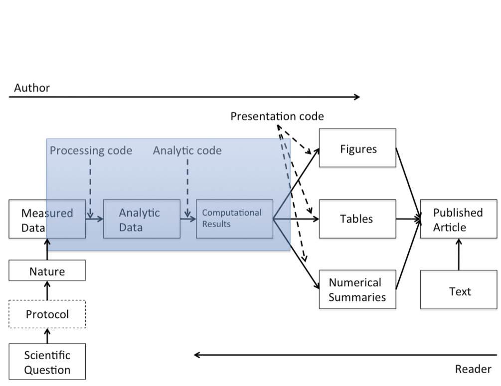

## reproducibility limitations

- top down
- downstream (post publication)
- ultimately does not address the key question:

  > can we trust these results?

## evidence based science

evdence needs:

- **documenting**
- **linking**
- **communicating**

`rmarkdown` can integrate **tools, processes** and **outputs** into **evidence streams**

> at all stages of scientific process

## simple tools:

### low hanging fruit

- begin at the start of the process
- document & interlink evidence streams
- explore and communicate!

> empower your code and data

## examples

### [code documentation](http://rpubs.com/annakrystalli/123196)

### [interactive documents](http://rpubs.com/annakrystalli/161760)

### [presentations](http://rpubs.com/annakrystalli/133391)

# md basics

## text

```
    normal text
```

normal text

```
    *italic text*
```

*italic text*

```
    **bold text**
```

**bold text**

```
    **bold italic text**
```

*bold italic text*

```
    superscript^2^
```

```
    ~~strikethrough~~
```

strikethrough

## headers

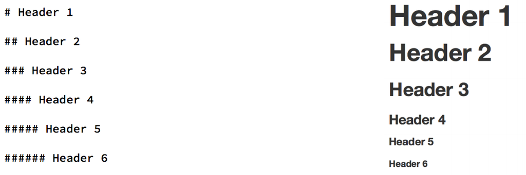

## unordered lists

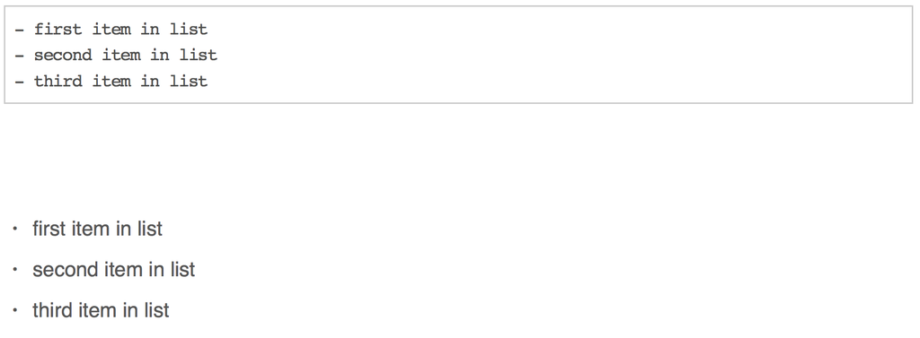

## ordered lists

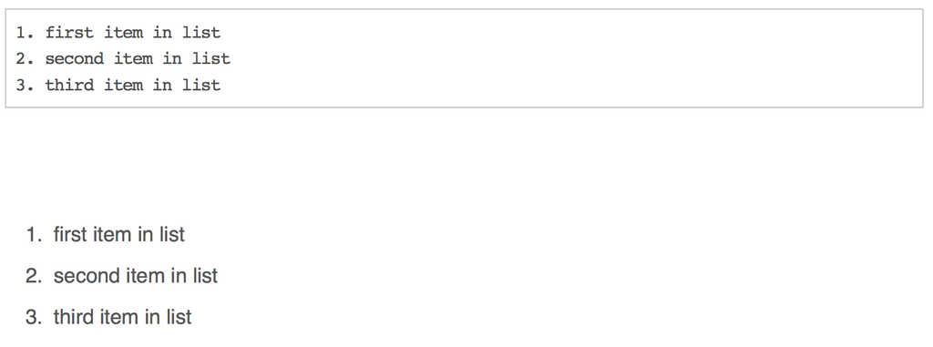

## quotes & code

```
> this text will be quoted
```

> this text will be quoted

```
`this text will appear as code` inline
```

`this text will appear as code` inline

```r
a <- 10
```

```
    the value of parameter *a* is `r a`
```

## images

```
    ![](https://www.rstudio.com/wp-content/uploads/2015/01/rmarkdown-cheatsheet-2-e1457627578814.png)

    ![](resources/cheat.png)
```

[figure not shown]

##

### resize images

```
    <img src="resources/cheat.png" width="200px" />
```

[figure not shown]

## basic tables

| Table Header | Second Header |
| --- | --- |
| Cell 1 | Cell 2 |
| Cell 3 | Cell 4 |

| Table Header | Second Header |
| --- | --- |
| Cell 1 | Cell 2 |
| Cell 3 | Cell 4 |

online table to .md converter

## links

```
[Download R](http://www.r-project.org/)
[RStudio](http://www.rstudio.com/)
```

[Download R](http://www.r-project.org/)

[RStudio](http://www.rstudio.com/)

## `.md` resources

[offical markdown documentation](http://daringfireball.net/projects/markdown/basics)

[Rmarkdown documentation](http://rmarkdown.rstudio.com/)

[Rstudio Rmarkdown cheatsheet](https://www.rstudio.com/wp-content/uploads/2015/02/rmarkdown-cheatsheet.pdf)

[gtihub .md basics](https://help.github.com/articles/basic-writing-and-formatting-syntax/)

[github.io websites: eg Andy South's blog](http://andysouth.github.io/blog-setup/)

[Reproducible Research](https://www.coursera.org/learn/reproducible-research) coursera MOOC

# chunks

##

R code chunks can be used as a means render R output into documents or to simply display code for illustration

[figure not shown]

## options

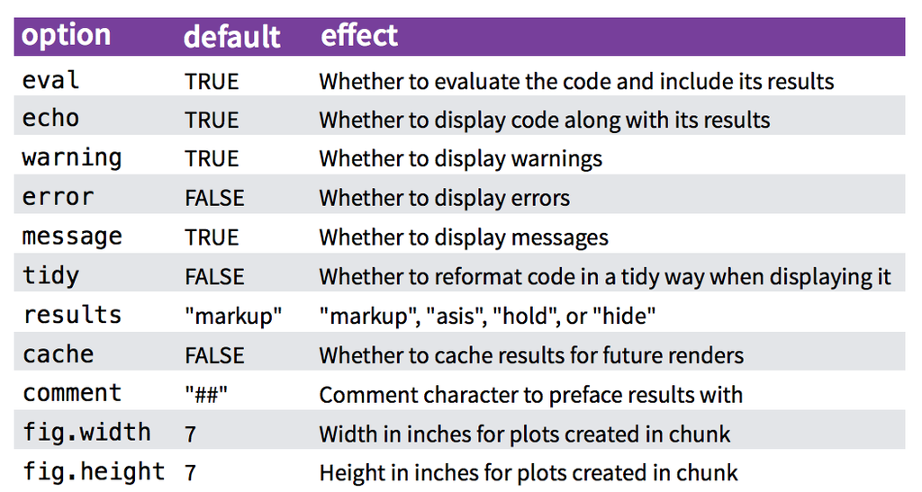

for more details see http://yihui.name/knitr/

# extras

## `knitr::kable()` tables

```r
require(knitr)
data(airquality)
kable(airquality, caption = "New York Air Quality Measurements")
```

[output not shown]

```r
require(DT)
data(airquality)
datatable(airquality, caption = "New York Air Quality Measurements")
```

[output not shown]

## plotly

```r
library(plotly)

set.seed(100)
d <- diamonds[sample(nrow(diamonds), 1000), ]

p <- ggplot(data = d, aes(x = carat, y = price)) +
  geom_point(aes(text = paste("Clarity:", clarity)), size = 1) +
  geom_smooth(aes(colour = cut, fill = cut)) + facet_wrap(~ cut)

ggplotly(p)
```

```r
library(plotly)

set.seed(100)
d <- diamonds[sample(nrow(diamonds), 1000), ]

p <- ggplot(data = d, aes(x = carat, y = price)) +
  geom_point(aes(text = paste("Clarity:", clarity)), size = 1) +
  geom_smooth(aes(colour = cut, fill = cut)) + facet_wrap(~ cut)

ggplotly(p)
```

[output not shown]

## shiny

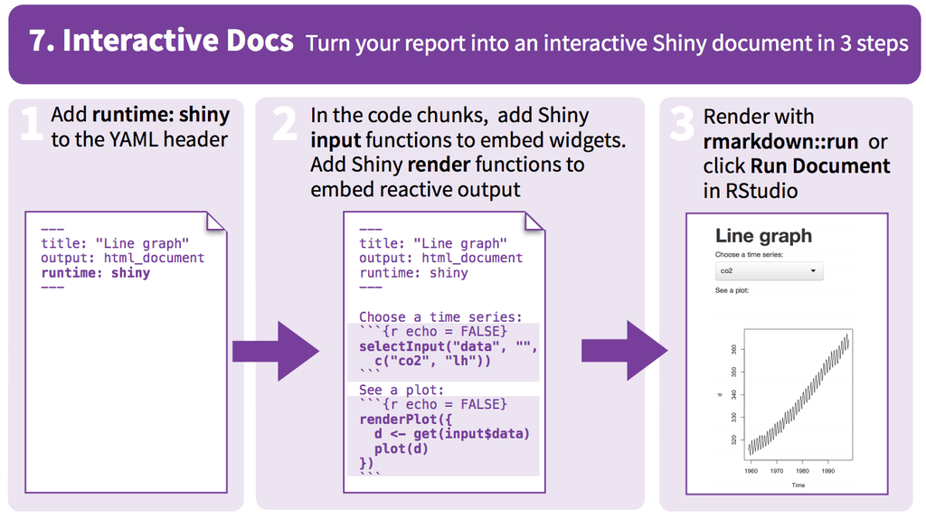

## outputs

[figure not shown]

## demo

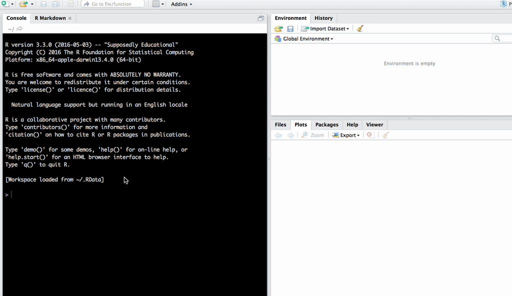

# Exercise

## your mission

> *create your first `.Rmd`!*
- get data from OSF
- show us some data in a table
- plot some data
- fit a model
- write a bit about what you did